# **PCFL 2023: Week 9 wrap-up**

### Point distribution by position

Here’s a breakdown of point contribution by position by team so far this season.

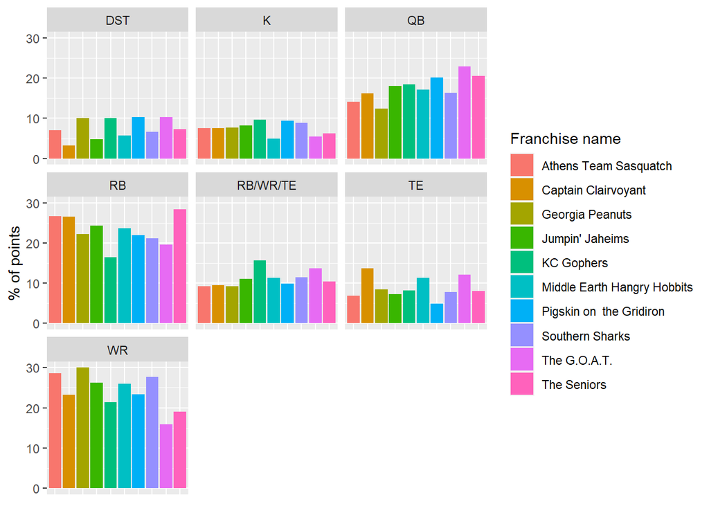

Fun facts:

- The Seniors have gotten 29% of their points from the RB position. The Gophers have the least at 17%.
- Brian has STILL gotten just **29 TOTAL POINTS** from his DST position ALL SEASON. I’m the leader with 112, but Evan is next to last with 52 points–almost double Brian’s total.
- Of the five top scoring positions in the league, 3 are WR (led by me with 334) and 2 are RB (led by Erin/Trav with 310). The lowest scoring position group is Brian’s DST.

### Best pick-ups

There were 10 players added last week. Which was the **best pick-ups**?

| PCFL Team | Player | NFL Team | Position | Points |
| --- | --- | --- | --- | --- |
| The Seniors | Russell Wilson | DEN | QB | 18.72 |
| Captain Clairvoyant | Jaylen Warren | PIT | RB | 18.00 |
| Georgia Peanuts | Kyler Murray | ARI | QB | 17.26 |
| Southern Sharks | Evan McPherson | CIN | K | 11.00 |
| Jumpin’ Jaheims | Logan Thomas | WAS | TE | 6.50 |
| Southern Sharks | Steelers D/ST | PIT | DST | 6.00 |
| Middle Earth Hangry Hobbits | Nick Folk | TEN | K | 5.00 |
| Athens Team Sasquatch | Taysom Hill | NOS | TE | 3.30 |
| The G.O.A.T. | Brandon McManus | JAC | K | 3.00 |
| Athens Team Sasquatch | Khalil Herbert | CHI | RB | 0.00 |

Check out Russell Wilson. And I let go of Jaylen Warren maybe too soon.

### Best team performances

Here’s a list of the **top five scoring performances** so far this season.

| PCFL Team | Week | Score | Result |
| --- | --- | --- | --- |
| Athens Team Sasquatch | 8 | 180.02 | W |
| Middle Earth Hangry Hobbits | 2 | 167.18 | W |
| Jumpin’ Jaheims | 4 | 149.98 | W |
| Georgia Peanuts | 4 | 148.64 | W |
| The Seniors | 3 | 146.88 | W |

No changes this week.

## Looking ahead

### League standings

| PCFL Team | Division | Points scored | Avg points | Avg last 3 | W | L | Team points |
| --- | --- | --- | --- | --- | --- | --- | --- |
| Georgia Peanuts | Hot Dish | 1114.70 | 111.47 | 108.96 | 6 | 4 | 13 |
| Middle Earth Hangry Hobbits | Hot Dish | 1113.26 | 111.33 | 119.43 | 6 | 4 | 13 |
| Southern Sharks | Hot Dish | 1067.07 | 106.71 | 96.48 | 5 | 5 | 12 |
| Athens Team Sasquatch | Grits | 1101.34 | 110.13 | 116.57 | 6 | 4 | 11 |
| Pigskin on the Gridiron | Grits | 1067.48 | 106.75 | 119.03 | 6 | 4 | 11 |
| The Seniors | Hot Dish | 1089.05 | 108.90 | 97.72 | 4 | 6 | 10 |
| Jumpin’ Jaheims | Grits | 1074.90 | 107.49 | 109.33 | 5 | 5 | 10 |
| The G.O.A.T. | Grits | 979.25 | 97.92 | 115.92 | 5 | 5 | 9 |
| KC Gophers | Hot Dish | 926.08 | 92.61 | 78.97 | 3 | 7 | 6 |
| Captain Clairvoyant | Grits | 893.58 | 89.36 | 87.26 | 4 | 6 | 5 |

Scott and I top the standings, though I win the points tiebreaker by 1.5.

### If the season ended today…

Playoffs currently stand as me, Scott, Sarah, and Robbie.

### This week’s matchups

| Team 1 | Team 2 |
| --- | --- |
| Athens Team Sasquatch (Avg. last 3: 116.57) | Pigskin on the Gridiron (Avg. last 3: 119.03) |
| Captain Clairvoyant (Avg. last 3: 87.26) | The G.O.A.T. (Avg. last 3: 115.92) |
| Georgia Peanuts (Avg. last 3: 108.96) | Middle Earth Hangry Hobbits (Avg. last 3: 119.43) |
| Jumpin’ Jaheims (Avg. last 3: 109.33) | KC Gophers (Avg. last 3: 78.97) |
| Southern Sharks (Avg. last 3: 96.48) | The Seniors (Avg. last 3: 97.72) |

It’s another #1 and #2 this week: me vs. Scott. Robbie vs. Richard is also a matchup of two hot teams.

Good luck, y’all!